# Statia Snake Analysis

D. S. Fernandez del Viso

20200622

**Season**: each year

## Loading data

Data from Hanna.  
*Note: occupancy = occurrence*.

```r
library(readxl)
Also2018 <- read_excel("Alsophis 2018 occupancy data_covariates.xlsx")
head(Also2018)
```

| Visit 1 | Visit 2 | Visit 3 | Visit 4 | Visit 5 | Visit 6 | Visit 7 | Visit 8 | Visit 9 | Visit 10 | Visit 11 | Visit 12 | Visit 13 | Visit 14 | Visit 15 | Visit 16 | Visit 17 | Visit 18 | Visit 19 | Visit 20 | Visit 21 | Visit 22 | Visit 23 | Visit 24 | habitat | elevation | Time_1 | Time_2 | Time_3 | Time_4 | … |
| --- | --- | --- | --- | --- | --- | --- | --- | --- | --- | --- | --- | --- | --- | --- | --- | --- | --- | --- | --- | --- | --- | --- | --- | --- | --- | --- | --- | --- | --- | --- |
| 0 | 0 | 0 | 0 | 0 | 0 | 0 | 0 | 0 | 0 | 0 | 0 | 0 | 0 | 0 | 0 | 0 | 0 | NA | NA | NA | NA | NA | NA | 6 | 13 | 5 | 3 | 5 | 3 | … |
| 0 | 0 | 0 | 0 | 0 | 0 | 0 | 0 | 0 | 0 | 0 | 0 | 1 | 0 | 0 | 0 | 0 | 0 | NA | NA | NA | NA | NA | NA | 6 | 16 | 10 | 3 | 5 | 6 | … |
| 0 | 0 | 0 | 0 | 0 | 0 | 0 | 0 | 0 | 0 | 0 | 0 | 0 | 0 | 0 | 0 | NA | NA | NA | NA | NA | NA | NA | NA | 6 | 20 | 5 | 5 | 8 | 4 | … |
| 0 | 0 | 0 | 0 | 0 | 0 | 0 | 0 | 0 | 0 | 0 | 0 | 0 | 0 | 0 | 0 | NA | NA | NA | NA | NA | NA | NA | NA | 7 | 24 | 7 | 8 | 9 | 5 | … |
| 0 | 0 | 0 | 0 | 0 | 0 | 0 | 0 | 0 | 0 | 0 | 0 | 0 | 0 | 0 | 0 | NA | NA | NA | NA | NA | NA | NA | NA | 7 | 33 | 8 | 7 | 9 | 5 | … |
| 0 | 0 | 0 | 0 | 0 | 0 | 0 | 0 | 0 | 0 | 0 | 0 | 0 | 0 | 0 | 0 | NA | NA | NA | NA | NA | NA | NA | NA | 7 | 45 | 9 | 7 | 7 | 4 | … |

```r
Also2019 <- read_excel("Alsophis 2019 occupancy data_covariates.xlsx")
head(Also2019)
```

| Visit 1 | Visit 2 | Visit 3 | Visit 4 | Visit 5 | Visit 6 | Visit 7 | Visit 8 | Visit 9 | Visit 10 | Visit 11 | Visit 12 | Visit 13 | Visit 14 | Visit 15 | Visit 16 | Visit 17 | Visit 18 | Visit 19 | Visit 20 | Visit 21 | Visit 22 | habitat | elevation | Cloud_1 | Cloud_2 | Cloud_3 | Cloud_4 | Cloud_5 | Cloud_6 | … |
| --- | --- | --- | --- | --- | --- | --- | --- | --- | --- | --- | --- | --- | --- | --- | --- | --- | --- | --- | --- | --- | --- | --- | --- | --- | --- | --- | --- | --- | --- | --- |
| 0 | 0 | 0 | 0 | 0 | NA | NA | NA | NA | NA | NA | NA | NA | NA | NA | NA | NA | NA | NA | NA | NA | NA | 3 | 13 | 4 | 0 | 0 | 4 | 3 | NA | … |
| 0 | 0 | 0 | 0 | 0 | NA | NA | NA | NA | NA | NA | NA | NA | NA | NA | NA | NA | NA | NA | NA | NA | NA | 7 | 13 | 3 | 0 | 1 | 4 | 3 | NA | … |
| 0 | 0 | 0 | 0 | 0 | 1 | 1 | NA | NA | NA | NA | NA | NA | NA | NA | NA | NA | NA | NA | NA | NA | NA | 3 | 16 | 3 | 2 | 2 | 0 | 0 | 2 | … |
| 0 | 0 | 0 | 0 | 1 | 0 | 0 | 0 | 0 | 0 | NA | NA | NA | NA | NA | NA | NA | NA | NA | NA | NA | NA | 3 | 18 | 2 | 4 | 1 | 0 | 3 | 4 | … |
| 0 | 0 | 1 | 0 | 0 | NA | NA | NA | NA | NA | NA | NA | NA | NA | NA | NA | NA | NA | NA | NA | NA | NA | 3 | 19 | 1 | 2 | 3 | 0 | 0 | NA | … |
| 0 | 0 | 0 | 0 | 0 | 0 | 0 | NA | NA | NA | NA | NA | NA | NA | NA | NA | NA | NA | NA | NA | NA | NA | 6 | 19 | 3 | 2 | 3 | 2 | 0 | 1 | … |

## Cleaning the names of the columns

```r
# install.packages("janitor")
library(janitor)
Also2018 <- clean_names(Also2018)
head(Also2018)
```

| visit_1 | visit_2 | visit_3 | visit_4 | visit_5 | visit_6 | visit_7 | visit_8 | visit_9 | visit_10 | visit_11 | visit_12 | visit_13 | visit_14 | visit_15 | visit_16 | visit_17 | visit_18 | visit_19 | visit_20 | visit_21 | visit_22 | visit_23 | visit_24 | habitat | elevation | time_1 | time_2 | time_3 | time_4 | … |
| --- | --- | --- | --- | --- | --- | --- | --- | --- | --- | --- | --- | --- | --- | --- | --- | --- | --- | --- | --- | --- | --- | --- | --- | --- | --- | --- | --- | --- | --- | --- |
| 0 | 0 | 0 | 0 | 0 | 0 | 0 | 0 | 0 | 0 | 0 | 0 | 0 | 0 | 0 | 0 | 0 | 0 | NA | NA | NA | NA | NA | NA | 6 | 13 | 5 | 3 | 5 | 3 | … |
| 0 | 0 | 0 | 0 | 0 | 0 | 0 | 0 | 0 | 0 | 0 | 0 | 1 | 0 | 0 | 0 | 0 | 0 | NA | NA | NA | NA | NA | NA | 6 | 16 | 10 | 3 | 5 | 6 | … |
| 0 | 0 | 0 | 0 | 0 | 0 | 0 | 0 | 0 | 0 | 0 | 0 | 0 | 0 | 0 | 0 | NA | NA | NA | NA | NA | NA | NA | NA | 6 | 20 | 5 | 5 | 8 | 4 | … |
| 0 | 0 | 0 | 0 | 0 | 0 | 0 | 0 | 0 | 0 | 0 | 0 | 0 | 0 | 0 | 0 | NA | NA | NA | NA | NA | NA | NA | NA | 7 | 24 | 7 | 8 | 9 | 5 | … |
| 0 | 0 | 0 | 0 | 0 | 0 | 0 | 0 | 0 | 0 | 0 | 0 | 0 | 0 | 0 | 0 | NA | NA | NA | NA | NA | NA | NA | NA | 7 | 33 | 8 | 7 | 9 | 5 | … |
| 0 | 0 | 0 | 0 | 0 | 0 | 0 | 0 | 0 | 0 | 0 | 0 | 0 | 0 | 0 | 0 | NA | NA | NA | NA | NA | NA | NA | NA | 7 | 45 | 9 | 7 | 7 | 4 | … |

```r
Also2019 <- clean_names(Also2019)
head(Also2019)
```

| visit_1 | visit_2 | visit_3 | visit_4 | visit_5 | visit_6 | visit_7 | visit_8 | visit_9 | visit_10 | visit_11 | visit_12 | visit_13 | visit_14 | visit_15 | visit_16 | visit_17 | visit_18 | visit_19 | visit_20 | visit_21 | visit_22 | habitat | elevation | cloud_1 | cloud_2 | cloud_3 | cloud_4 | cloud_5 | cloud_6 | … |
| --- | --- | --- | --- | --- | --- | --- | --- | --- | --- | --- | --- | --- | --- | --- | --- | --- | --- | --- | --- | --- | --- | --- | --- | --- | --- | --- | --- | --- | --- | --- |
| 0 | 0 | 0 | 0 | 0 | NA | NA | NA | NA | NA | NA | NA | NA | NA | NA | NA | NA | NA | NA | NA | NA | NA | 3 | 13 | 4 | 0 | 0 | 4 | 3 | NA | … |
| 0 | 0 | 0 | 0 | 0 | NA | NA | NA | NA | NA | NA | NA | NA | NA | NA | NA | NA | NA | NA | NA | NA | NA | 7 | 13 | 3 | 0 | 1 | 4 | 3 | NA | … |
| 0 | 0 | 0 | 0 | 0 | 1 | 1 | NA | NA | NA | NA | NA | NA | NA | NA | NA | NA | NA | NA | NA | NA | NA | 3 | 16 | 3 | 2 | 2 | 0 | 0 | 2 | … |
| 0 | 0 | 0 | 0 | 1 | 0 | 0 | 0 | 0 | 0 | NA | NA | NA | NA | NA | NA | NA | NA | NA | NA | NA | NA | 3 | 18 | 2 | 4 | 1 | 0 | 3 | 4 | … |
| 0 | 0 | 1 | 0 | 0 | NA | NA | NA | NA | NA | NA | NA | NA | NA | NA | NA | NA | NA | NA | NA | NA | NA | 3 | 19 | 1 | 2 | 3 | 0 | 0 | NA | … |
| 0 | 0 | 0 | 0 | 0 | 0 | 0 | NA | NA | NA | NA | NA | NA | NA | NA | NA | NA | NA | NA | NA | NA | NA | 6 | 19 | 3 | 2 | 3 | 2 | 0 | 1 | … |

## Using occSS

**occSS**: allows for psi or p to be modelled as a logistic function of site covariates or survey covariates, as specified by model. It includes a built in .time covariate which can be used for modelling p with time as a fixed effect, and .Time for a linear or quadratic trend. A built-in .b covariate corresponds to a behavioural effect, where detection depends on whether the species was detected on the previous occasion or not.

*link*: function to link the response on a (0,1) scale to a linear predictor on (-Inf, Inf). The canonical link is the logistic (“logit”) function, which has some nice theoretical properties and can be interpreted as the log of the odds of success. Other links are available, notably the cumulative standard normal (“probit”) link, which allows for Gibbs sampling with truncated normal distributions. For that reason, several of the Bayesian estimation functions in wiqid use the probit link.

```r
library(wiqid)
#extraction of occupancy matrix DH
Also2018DH <- Also2018[,1:24]
Also2019DH <- Also2019[,1:22]
#with link
#2018 logit
occSS(Also2018DH, link=c("logit"))
```

```
## Call: occSS0(y = y, n = n, ci = ci, link = link)
##
## Real values:
##            est   lowCI   uppCI
## psiHat 0.72756 0.42788 0.90509
## pHat   0.05016 0.03332 0.07486
##
## AIC: 438.1761
```

```r
#2019 logit
occSS(Also2019DH, link=c("logit"))
```

```
## Call: occSS0(y = y, n = n, ci = ci, link = link)
##
## Real values:
##            est   lowCI  uppCI
## psiHat 0.64983 0.37361 0.8524
## pHat   0.07282 0.04566 0.1142
##
## AIC: 403.9795
```

```r
#2018 probit
occSS(Also2018DH, link=c("probit"))
```

```
## Call: occSS0(y = y, n = n, ci = ci, link = link)
##
## Real values:
##            est   lowCI   uppCI
## psiHat 0.72756 0.43872 0.91390
## pHat   0.05016 0.03289 0.07399
##
## AIC: 438.1761
```

```r
#2019 probit
occSS(Also2019DH, link=c("probit"))
```

```
## Call: occSS0(y = y, n = n, ci = ci, link = link)
##
## Real values:
##            est   lowCI  uppCI
## psiHat 0.64982 0.37736 0.8604
## pHat   0.07282 0.04486 0.1125
##
## AIC: 403.9795
```

```r
#A built-in .b covariate corresponds to a behavioural effect, where detection depends on whether the species was detected on the previous occasion or not.
#2018
occSS(Also2018DH, p ~ .b)
```

```
## Call: occSS(DH = Also2018DH, model = p ~ .b)
##
## Real values (duplicates omitted):
##            est   lowCI   uppCI
## psi:1  0.76782 0.39536 0.94359
## p:1,1  0.04584 0.02897 0.07182
## p:27,2 0.08696 0.03302 0.20985
##
## AIC: 438.9366
```

```r
#2019
occSS(Also2019DH, p ~ .b)
```

```
## Call: occSS(DH = Also2019DH, model = p ~ .b)
##
## Real values (duplicates omitted):
##           est   lowCI  uppCI
## psi:1 0.64803 0.35781 0.8588
## p:1,1 0.07313 0.04370 0.1199
## p:7,2 0.07143 0.02322 0.1993
##
## AIC: 405.9781
```

*occSS0*:implements a simple model with one parameter for probability of occupancy and one for probability of detection, ie. a psi(.) p(.) model.

```r
#2018
# with Also2018DH 24 visits
y <- rowSums(Also2018DH, na.rm=TRUE)
n <- rowSums(!is.na(Also2018DH))
# occSS0 is a faster simple form of occSS
occSS0(y, n)
```

```
## Call: occSS0(y = y, n = n)
##
## Real values:
##            est   lowCI   uppCI
## psiHat 0.72756 0.42788 0.90509
## pHat   0.05016 0.03332 0.07486
##
## AIC: 438.1761
```

```r
# with Also2019DH 22 visits
y <- rowSums(Also2019DH, na.rm=TRUE)
n <- rowSums(!is.na(Also2019DH))
# occSS0 is a faster simple form of occSS
occSS0(y, n)
```

```
## Call: occSS0(y = y, n = n)
##
## Real values:
##            est   lowCI  uppCI
## psiHat 0.64983 0.37361 0.8524
## pHat   0.07282 0.04566 0.1142
##
## AIC: 403.9795
```

## Other occSSs

**occSStime**: allows for time-varying covariates that are the same across all sites, eg, moon-phase. A categorical time variable .time and a time trend .Time are built-in. A plot of detection probability vs time is produced if plot=TRUE.

```r
#time effect accross all sites
#2018
time <- occSStime(Also2018DH, p ~ .time)
```

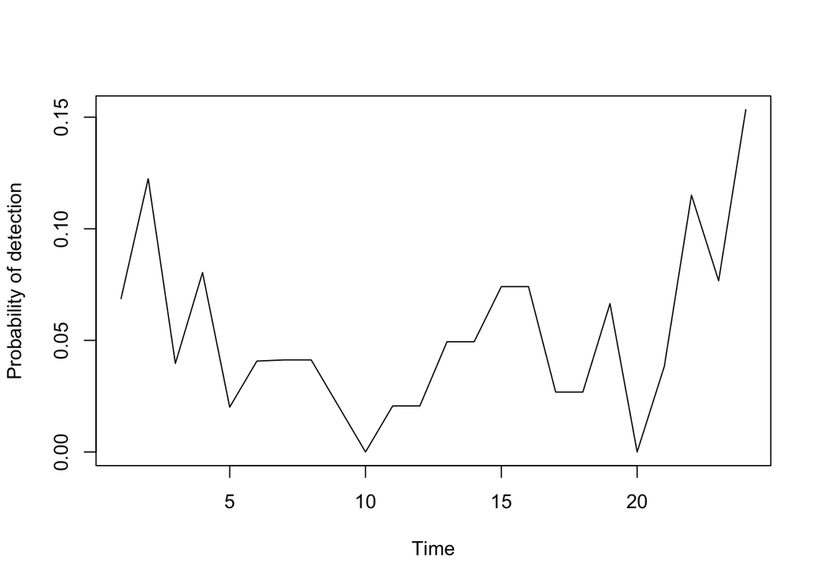

```r
time[["real"]]
```

```
##              est lowCI uppCI
## psi 7.184172e-01    NA    NA
## p1  6.873750e-02    NA    NA
## p2  1.223951e-01    NA    NA
## p3  3.965567e-02    NA    NA
## p4  8.037591e-02    NA    NA
## p5  2.009536e-02    NA    NA
## p6  4.071421e-02    NA    NA
## p7  4.124665e-02    NA    NA
## p8  4.124665e-02    NA    NA
## p9  2.062295e-02    NA    NA
## p10 3.131567e-10    NA    NA
## p11 2.062295e-02    NA    NA
## p12 2.062295e-02    NA    NA
## p13 4.939186e-02    NA    NA
## p14 4.939186e-02    NA    NA
## p15 7.408685e-02    NA    NA
## p16 7.408682e-02    NA    NA
## p17 2.682846e-02    NA    NA
## p18 2.682846e-02    NA    NA
## p19 6.646634e-02    NA    NA
## p20 2.217472e-09    NA    NA
## p21 3.834787e-02    NA    NA
## p22 1.150430e-01    NA    NA
## p23 7.669844e-02    NA    NA
## p24 1.533911e-01    NA    NA
```

```r
# trend linear
Time <- occSStime(Also2018DH, p ~ .Time)
```

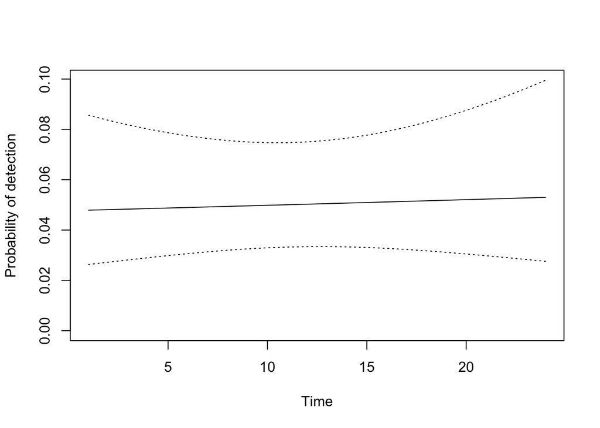

```r
Time[["real"]]
```

```
##            est      lowCI      uppCI
## psi 0.72950574 0.42789513 0.90675796
## p1  0.04789495 0.02631721 0.08560896
## p2  0.04810682 0.02722857 0.08361792
## p3  0.04831958 0.02812650 0.08178997
## p4  0.04853323 0.02900042 0.08013630
## p5  0.04874778 0.02983790 0.07867007
## p6  0.04896323 0.03062464 0.07740640
## p7  0.04917958 0.03134482 0.07636208
## p8  0.04939683 0.03198171 0.07555493
## p9  0.04961500 0.03251864 0.07500280
## p10 0.04983408 0.03294046 0.07472221
## p11 0.05005408 0.03323502 0.07472675
## p12 0.05027499 0.03339469 0.07502565
## p13 0.05049683 0.03341726 0.07562282
## p14 0.05071960 0.03330616 0.07651667
## p15 0.05094330 0.03306979 0.07770076
## p16 0.05116793 0.03272032 0.07916500
## p17 0.05139349 0.03227216 0.08089717
## p18 0.05162000 0.03174057 0.08288432
## p19 0.05184745 0.03114051 0.08511389
## p20 0.05207585 0.03048595 0.08757443
## p21 0.05230520 0.02978939 0.09025605
## p22 0.05253550 0.02906172 0.09315054
## p23 0.05276676 0.02831226 0.09625134
## p24 0.05299898 0.02754885 0.09955348
```

```r
# trend quadratic
Time2 <- occSStime(Also2018DH, p ~ .Time + I(.Time^2))
```

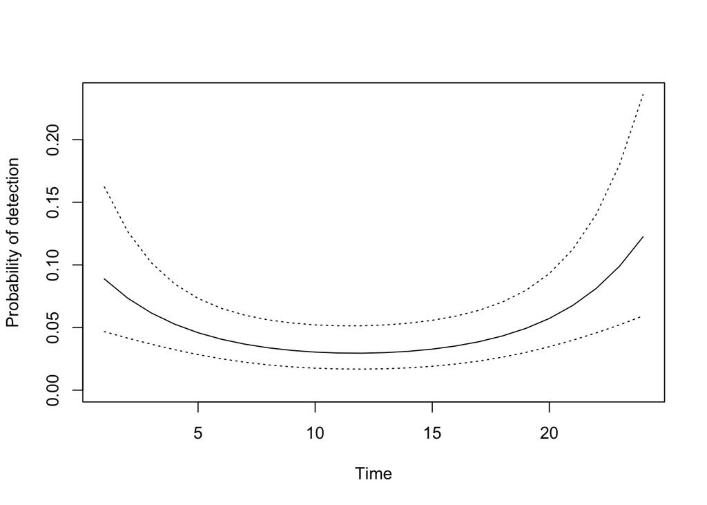

```r
Time2[["real"]]
```

```
##            est      lowCI      uppCI
## psi 0.73744098 0.42776332 0.91344182
## p1  0.08878875 0.04673287 0.16224989
## p2  0.07340268 0.04151664 0.12654493
## p3  0.06166663 0.03671059 0.10179512
## p4  0.05270372 0.03231623 0.08482568
## p5  0.04585858 0.02840138 0.07323721
## p6  0.04064704 0.02504968 0.06530568
## p7  0.03671455 0.02230801 0.05985527
## p8  0.03380425 0.02017098 0.05612423
## p9  0.03173322 0.01859798 0.05363850
## p10 0.03037567 0.01753780 0.05211252
## p11 0.02965128 0.01694653 0.05138291
## p12 0.02951798 0.01679709 0.05136940
## p13 0.02996807 0.01708360 0.05205536
## p14 0.03102758 0.01782292 0.05348258
## p15 0.03275859 0.01905435 0.05575893
## p16 0.03526488 0.02083680 0.05908064
## p17 0.03870141 0.02324094 0.06377508
## p18 0.04328862 0.02633318 0.07037230
## p19 0.04933280 0.03015178 0.07971291
## p20 0.05725409 0.03468649 0.09308861
## p21 0.06762354 0.03988518 0.11239443
## p22 0.08120969 0.04569835 0.14026039
## p23 0.09903206 0.05213289 0.18010538
## p24 0.12241159 0.05927587 0.23592900
```

```r
#2019
time <- occSStime(Also2019DH, p ~ .time)
```

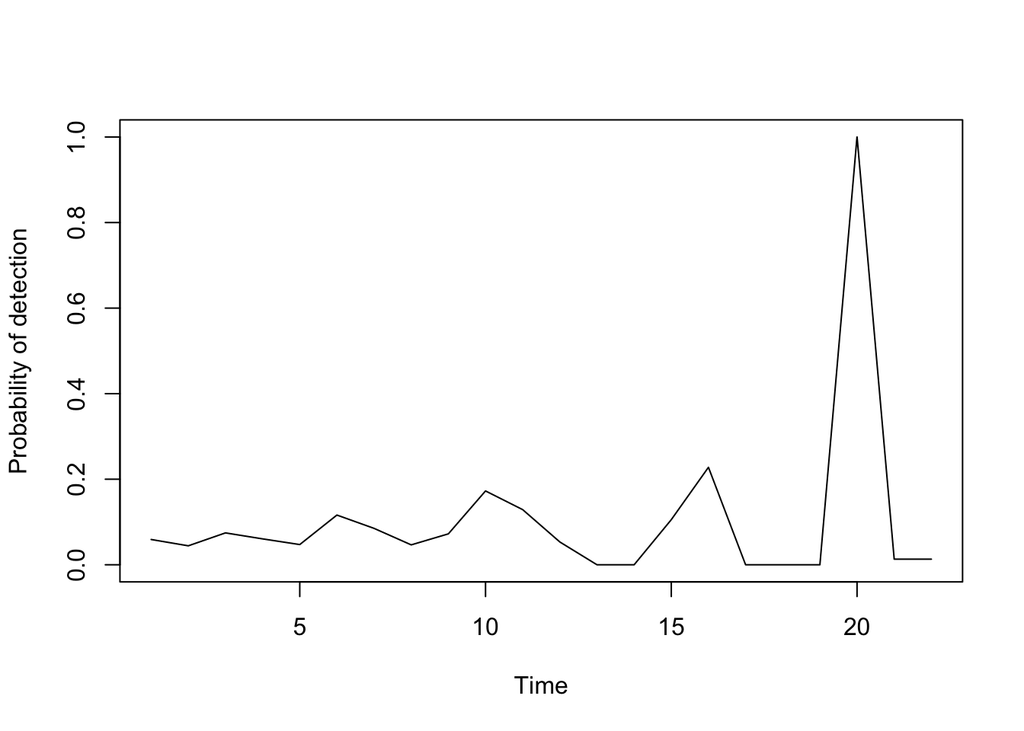

```r
time[["real"]]
```

```
##              est lowCI uppCI
## psi 6.267804e-01    NA    NA
## p1  5.909162e-02    NA    NA
## p2  4.431473e-02    NA    NA
## p3  7.452641e-02    NA    NA
## p4  6.052163e-02    NA    NA
## p5  4.722960e-02    NA    NA
## p6  1.162085e-01    NA    NA
## p7  8.509604e-02    NA    NA
## p8  4.651314e-02    NA    NA
## p9  7.227290e-02    NA    NA
## p10 1.725648e-01    NA    NA
## p11 1.288880e-01    NA    NA
## p12 5.330366e-02    NA    NA
## p13 1.072302e-20    NA    NA
## p14 2.402532e-18    NA    NA
## p15 1.054292e-01    NA    NA
## p16 2.277943e-01    NA    NA
## p17 9.466957e-13    NA    NA
## p18 5.513520e-10    NA    NA
## p19 2.751518e-07    NA    NA
## p20 1.000000e+00    NA    NA
## p21 1.309008e-02    NA    NA
## p22 1.309008e-02    NA    NA
```

```r
# trend linear
Time <- occSStime(Also2019DH, p ~ .Time)
```

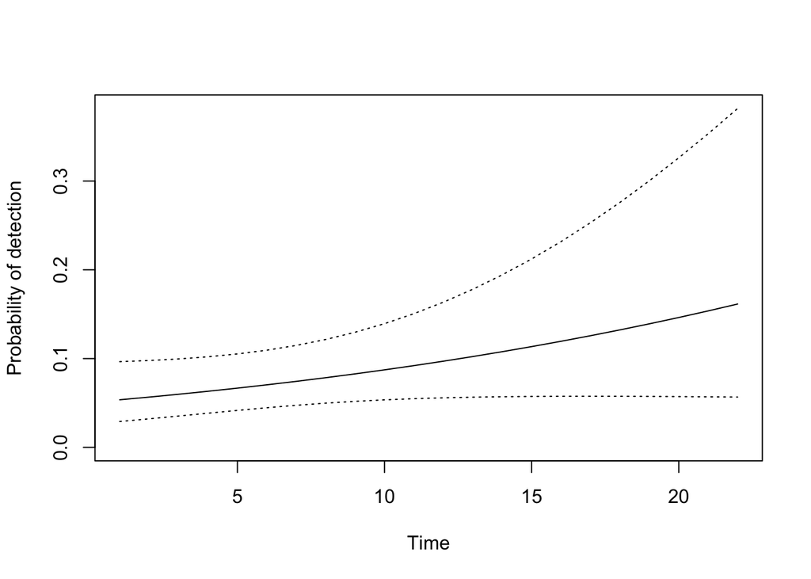

```r
Time[["real"]]
```

```
##            est      lowCI      uppCI
## psi 0.65534698 0.38984420 0.84982389
## p1  0.05356992 0.02910943 0.09654064
## p2  0.05660363 0.03213874 0.09780986
## p3  0.05979829 0.03528334 0.09958798
## p4  0.06316119 0.03847322 0.10201052
## p5  0.06669978 0.04161779 0.10523816
## p6  0.07042172 0.04461380 0.10944858
## p7  0.07433481 0.04736054 0.11482063
## p8  0.07844699 0.04977854 0.12151479
## p9  0.08276631 0.05182346 0.12965816
## p10 0.08730093 0.05348888 0.13934016
## p11 0.09205906 0.05479825 0.15061853
## p12 0.09704893 0.05579237 0.16352961
## p13 0.10227881 0.05651796 0.17809685
## p14 0.10775689 0.05702030 0.19433501
## p15 0.11349128 0.05733956 0.21225024
## p16 0.11948997 0.05750965 0.23183746
## p17 0.12576074 0.05755842 0.25307627
## p18 0.13231115 0.05750842 0.27592656
## p19 0.13914844 0.05737782 0.30032434
## p20 0.14627949 0.05718121 0.32617844
## p21 0.15371073 0.05693036 0.35336829
## p22 0.16144810 0.05663479 0.38174330
```

```r
# trend quadratic
Time2 <- occSStime(Also2019DH, p ~ .Time + I(.Time^2))
```

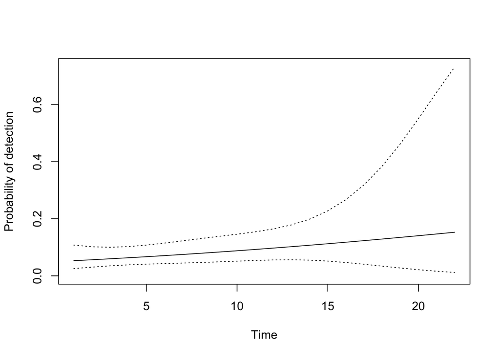

```r
Time2[["real"]]
```

```
##            est      lowCI     uppCI
## psi 0.65511215 0.38927921 0.8498618
## p1  0.05298617 0.02527060 0.1077390
## p2  0.05625356 0.03042855 0.1016975
## p3  0.05966720 0.03494048 0.1000779
## p4  0.06322920 0.03842132 0.1023501
## p5  0.06694135 0.04093635 0.1076125
## p6  0.07080508 0.04288636 0.1147202
## p7  0.07482145 0.04470374 0.1226254
## p8  0.07899112 0.04668216 0.1305979
## p9  0.08331432 0.04894201 0.1383158
## p10 0.08779086 0.05141936 0.1459318
## p11 0.09242008 0.05383256 0.1541607
## p12 0.09720085 0.05565852 0.1643531
## p13 0.10213156 0.05621837 0.1784518
## p14 0.10721012 0.05494090 0.1987489
## p15 0.11243392 0.05165613 0.2275625
## p16 0.11779988 0.04665785 0.2670326
## p17 0.12330438 0.04052607 0.3189572
## p18 0.12894334 0.03390750 0.3843690
## p19 0.13471218 0.02737190 0.4627296
## p20 0.14060582 0.02134617 0.5510146
## p21 0.14661876 0.01609818 0.6433831
## p22 0.15274500 0.01174963 0.7321681
```

**Question:** From above results, can we establish how many visits are enough?

**occSScovSite**: allows for site covariates but not for occasion or survey covariates.

```r
#2018
y <- rowSums(Also2018DH, na.rm=TRUE)
n <- rowSums(!is.na(Also2018DH))
# model habitat
occSScovSite(y, n, model = psi ~ habitat, data = Also2018)
```

```
## Call: occSScovSite(y = y, n = n, model = psi ~ habitat, data = Also2018)
##
## Real values (duplicates omitted):
##            est   lowCI   uppCI
## psi:1  0.71460 0.41421 0.89864
## psi:4  0.68001 0.37316 0.88353
## psi:16 0.85043 0.23215 0.99073
## psi:21 0.74685 0.41320 0.92515
## psi:34 0.80375 0.33548 0.97078
## psi:47 0.64332 0.29646 0.88532
## psi:56 0.77659 0.38214 0.95131
## psi:75 0.82835 0.28336 0.98330
## p:1    0.05006 0.03343 0.07433
##
## AIC: 439.6284
```

```r
# model elevation
occSScovSite(y, n, model = psi ~ elevation, data = Also2018)
```

```
## Call: occSScovSite(y = y, n = n, model = psi ~ elevation, data = Also2018)
##
## Real values (duplicates omitted):
##            est    lowCI   uppCI
## psi:1  0.04796 0.001877 0.57437
## psi:2  0.05231 0.002262 0.57344
## psi:3  0.05870 0.002896 0.57245
## psi:4  0.06582 0.003704 0.57178
## psi:5  0.08484 0.006397 0.57171
## psi:6  0.11790 0.012998 0.57567
## psi:7  0.13119 0.016352 0.57835
## psi:8  0.13830 0.018311 0.58001
## psi:9  0.14957 0.021650 0.58294
## psi:10 0.16158 0.025523 0.58644
## psi:11 0.18331 0.033323 0.59376
## psi:12 0.22801 0.052288 0.61256
## psi:14 0.24451 0.060143 0.62075
## psi:15 0.30509 0.091619 0.65648
## psi:16 0.38042 0.132377 0.71189
## psi:17 0.48479 0.181698 0.79950
## psi:18 0.53049 0.198884 0.83719
## psi:19 0.70139 0.239795 0.94592
## psi:20 0.70774 0.240700 0.94872
## psi:21 0.74987 0.245732 0.96502
## psi:23 0.77736 0.248110 0.97365
## psi:24 0.78260 0.248480 0.97512
## psi:26 0.78774 0.248819 0.97651
## psi:27 0.81212 0.250059 0.98247
## psi:28 0.82568 0.250478 0.98532
## psi:29 0.83428 0.250636 0.98698
## psi:31 0.84254 0.250704 0.98845
## psi:32 0.86173 0.250518 0.99147
## psi:33 0.87892 0.249883 0.99372
## psi:34 0.88212 0.249709 0.99409
## psi:35 0.90781 0.247528 0.99662
## psi:36 0.91980 0.245911 0.99753
## psi:37 0.93420 0.243256 0.99841
## psi:38 0.93785 0.242425 0.99860
## psi:39 0.95342 0.237875 0.99926
## psi:40 0.95732 0.236400 0.99939
```

[output cut: 26 more lines]

```
## psi:69 0.99925 0.157686 1.00000
## psi:70 0.99938 0.154335 1.00000
## psi:71 0.99954 0.148848 1.00000
## psi:72 0.99980 0.134680 1.00000
## psi:74 0.99987 0.127233 1.00000
## psi:75 0.99990 0.122914 1.00000
## psi:76 0.99993 0.116873 1.00000
## psi:77 0.99999 0.096192 1.00000
## psi:78 0.99999 0.084406 1.00000
## psi:79 0.99999 0.083713 1.00000
## psi:80 1.00000 0.078341 1.00000
## psi:81 0.85806 0.250593 0.99093
## p:1    0.04889 0.036218 0.06568
##
## AIC: 427.0842
```

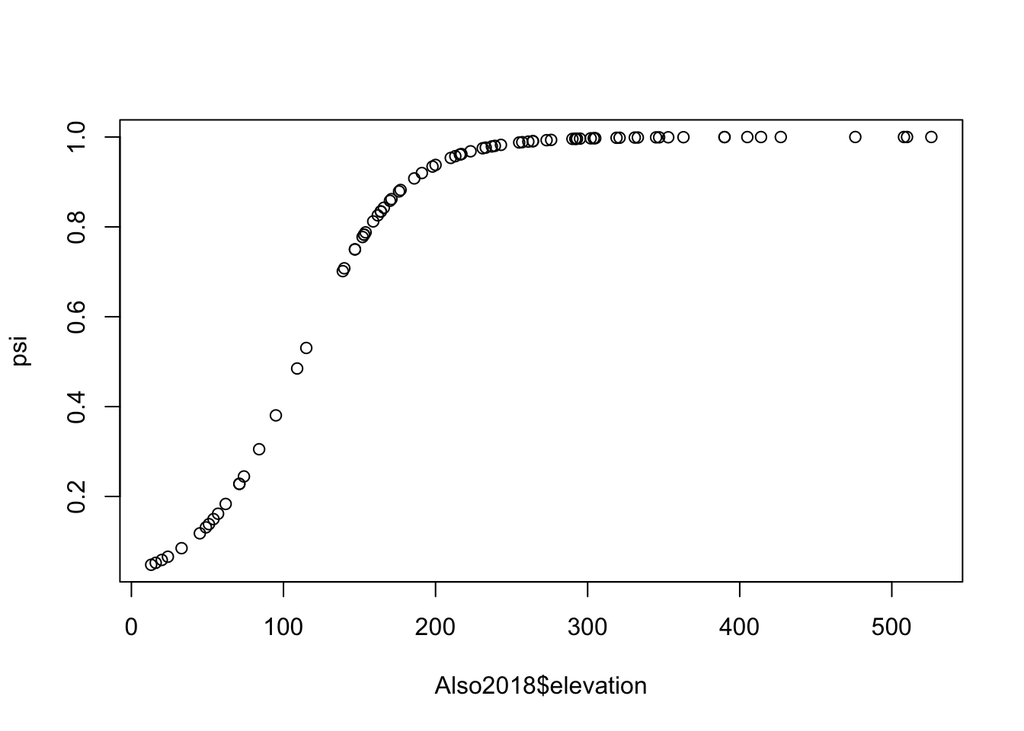

```r
res1 <- occSScovSite(y, n, model = psi ~ elevation, data = Also2018)
# plot psi vs elevation
psi <- as.data.frame(res1[["real"]])
psi <- psi[1:81,1]
plot(Also2018$elevation,psi)
```

```r
#2019
y <- rowSums(Also2019DH, na.rm=TRUE)
n <- rowSums(!is.na(Also2019DH))
# model habitat
occSScovSite(y, n, model = psi ~ habitat, data = Also2019)
```

```
## Call: occSScovSite(y = y, n = n, model = psi ~ habitat, data = Also2019)
##
## Real values (duplicates omitted):
##           est   lowCI  uppCI
## psi:1  0.5597 0.27822 0.8074
## psi:2  0.7404 0.28402 0.9535
## psi:6  0.6997 0.31386 0.9223
## psi:33 0.4591 0.14153 0.8137
## psi:40 0.6557 0.33019 0.8803
## psi:64 0.5095 0.21066 0.8017
## psi:67 0.7773 0.24875 0.9735
## psi:74 0.6087 0.32116 0.8365
## p:1    0.0711 0.04279 0.1159
##
## AIC: 404.991
```

```r
# model elevation
occSScovSite(y, n, model = psi ~ elevation, data = Also2019)
```

```
## Call: occSScovSite(y = y, n = n, model = psi ~ elevation, data = Also2019)
##
## Real values (duplicates omitted):
##             est   lowCI  uppCI
## psi:1   0.68615 0.32065 0.9101
## psi:3   0.68563 0.32218 0.9092
## psi:4   0.68528 0.32318 0.9085
## psi:5   0.68511 0.32369 0.9082
## psi:7   0.68476 0.32469 0.9075
## psi:8   0.68442 0.32568 0.9069
## psi:9   0.68355 0.32815 0.9052
## psi:10  0.68320 0.32912 0.9046
## psi:11  0.68181 0.33296 0.9019
## psi:13  0.68164 0.33344 0.9016
## psi:14  0.68042 0.33670 0.8993
## psi:15  0.67955 0.33898 0.8976
## psi:17  0.67902 0.34032 0.8966
## psi:18  0.67780 0.34339 0.8943
## psi:19  0.67762 0.34383 0.8940
## psi:20  0.67622 0.34720 0.8913
## psi:21  0.67552 0.34883 0.8900
## psi:23  0.67516 0.34963 0.8893
## psi:25  0.67499 0.35003 0.8890
## psi:27  0.67446 0.35121 0.8880
## psi:28  0.67393 0.35237 0.8870
## psi:29  0.67234 0.35571 0.8841
## psi:30  0.67146 0.35748 0.8825
## psi:32  0.67093 0.35850 0.8815
## psi:33  0.67057 0.35917 0.8809
## psi:34  0.66862 0.36266 0.8774
## psi:35  0.66844 0.36296 0.8771
## psi:36  0.66381 0.36962 0.8693
## psi:37  0.66327 0.37024 0.8684
## psi:38  0.66165 0.37191 0.8659
## psi:39  0.66129 0.37224 0.8654
## psi:40  0.66112 0.37240 0.8651
## psi:41  0.66076 0.37271 0.8646
## psi:42  0.66058 0.37286 0.8643
## psi:43  0.65986 0.37341 0.8633
## psi:44  0.65968 0.37354 0.8630
```

[output cut: 38 more lines]

```
## psi:95  0.62430 0.32150 0.8535
## psi:97  0.62015 0.30738 0.8573
## psi:98  0.61713 0.29653 0.8604
## psi:99  0.61561 0.29096 0.8621
## psi:100 0.61352 0.28317 0.8645
## psi:101 0.61181 0.27672 0.8665
## psi:102 0.61085 0.27310 0.8677
## psi:104 0.60070 0.23427 0.8809
## psi:105 0.59588 0.21614 0.8875
## psi:106 0.59414 0.20971 0.8898
## psi:107 0.59066 0.19708 0.8945
## psi:108 0.59007 0.19501 0.8953
## p:1     0.07291 0.04582 0.1141
##
## AIC: 405.8647
```

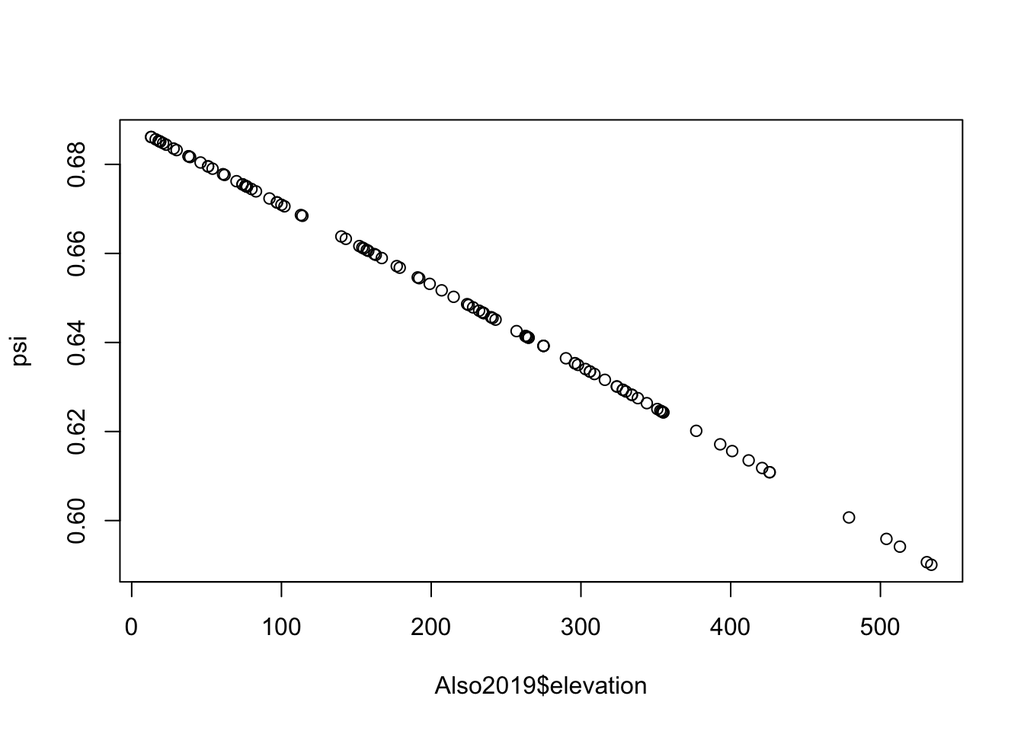

```r
res2 <- occSScovSite(y, n, model = psi ~ elevation, data = Also2019)
# plot psi vs elevation
psi <- as.data.frame(res2[["real"]])
psi <- psi[1:108,1]
plot(Also2019$elevation,psi)
```

## Royle-Nichols functions

These functions implement the Royle-Nichols method (Royle & Nichols 2003) for estimation of site occupancy allowing for abundance-induced heterogeneity in detection probability. Probability of detection is modelled as a function of the number of animals available for detection, n, and the probability of detection of an individual animal, r. Probability of occupancy is derived as the probability that n > 0.

Function occSSrn allows for site-specific covariates to be included in the model. occSSrnSite and occSSrn0 are fast alternatives that do not require a full detection history matrix.

```r
# 2018
#basic model
occSSrn(Also2018DH)
```

```
## Call: occSSrn0(y = y, n = n, ci = ci, link = link)
##
## Real values:
##               est    lowCI   uppCI
## psiHat    0.83740 0.482172 0.99335
## lambdaHat 1.81643 0.658112 5.01348
## rHat      0.02048 0.007266 0.05636
##
## AIC: 435.0417
```

```r
# 2019
#basic model
occSSrn(Also2019DH)
```

```
## Call: occSSrn0(y = y, n = n, ci = ci, link = link)
##
## Real values:
##               est    lowCI  uppCI
## psiHat    0.79876 0.320573 0.9987
## lambdaHat 1.60326 0.386505 6.6504
## rHat      0.03012 0.006932 0.1214
##
## AIC: 405.8
```

```r
#lambda - elevation
#2018
occSSrn(Also2018DH, model = lambda ~ elevation, data = Also2018)
```

```
## Call: occSSrnSite(y = y, n = n, model = model, data = data, ci = ci,
##     link = link)
##
## Real values (duplicates omitted):
##                est     lowCI     uppCI
## psi:1      0.99251 9.765e-02 1.000e+00
## psi:2      0.99306 9.921e-02 1.000e+00
## psi:3      0.99374 1.013e-01 1.000e+00
## psi:4      0.99436 1.035e-01 1.000e+00
## psi:5      0.99559 1.085e-01 1.000e+00
## psi:6      0.99687 1.155e-01 1.000e+00
## psi:7      0.99722 1.180e-01 1.000e+00
## psi:8      0.99739 1.192e-01 1.000e+00
## psi:9      0.99762 1.211e-01 1.000e+00
## psi:10     0.99783 1.230e-01 1.000e+00
## psi:11     0.99815 1.262e-01 1.000e+00
## psi:12     0.99863 1.322e-01 1.000e+00
## psi:14     0.99876 1.342e-01 1.000e+00
## psi:15     0.99913 1.413e-01 1.000e+00
## psi:16     0.99942 1.494e-01 1.000e+00
## psi:17     0.99967 1.603e-01 1.000e+00
## psi:18     0.99974 1.652e-01 1.000e+00
## psi:19     0.99991 1.860e-01 1.000e+00
## psi:20     0.99992 1.869e-01 1.000e+00
## psi:21     0.99994 1.934e-01 1.000e+00
## psi:23     0.99995 1.982e-01 1.000e+00
## psi:24     0.99996 1.991e-01 1.000e+00
## psi:26     0.99996 2.001e-01 1.000e+00
## psi:27     0.99997 2.050e-01 1.000e+00
## psi:28     0.99997 2.080e-01 1.000e+00
## psi:29     0.99998 2.100e-01 1.000e+00
## psi:31     0.99998 2.120e-01 1.000e+00
## psi:32     0.99998 2.171e-01 1.000e+00
## psi:33     0.99999 2.224e-01 1.000e+00
## psi:34     0.99999 2.234e-01 1.000e+00
## psi:35     0.99999 2.332e-01 1.000e+00
## psi:36     0.99999 2.387e-01 1.000e+00
## psi:37     1.00000 2.466e-01 1.000e+00
## psi:38     1.00000 2.489e-01 1.000e+00
## psi:39     1.00000 2.607e-01 1.000e+00
```

[output cut: 101 more lines]

```
## lambda:69 27.13570 6.238e-01 1.181e+03
## lambda:70 27.98356 6.436e-01 1.217e+03
## lambda:71 29.45596 6.780e-01 1.280e+03
## lambda:72 33.83003 7.798e-01 1.468e+03
## lambda:74 36.53487 8.426e-01 1.584e+03
## lambda:75 38.26050 8.825e-01 1.659e+03
## lambda:76 40.89797 9.435e-01 1.773e+03
## lambda:77 52.58057 1.211e+00 2.282e+03
## lambda:78 61.95688 1.424e+00 2.696e+03
## lambda:79 62.59557 1.438e+00 2.724e+03
## lambda:80 67.94785 1.559e+00 2.962e+03
## lambda:81 10.94864 2.435e-01 4.923e+02
## r:1        0.00201 4.515e-05 8.245e-02
##
## AIC: 417.319
```

```r
#2019
occSSrn(Also2019DH, model = lambda ~ elevation, data = Also2019)
```

```
## Call: occSSrnSite(y = y, n = n, model = model, data = data, ci = ci,
##     link = link)
##
## Real values (duplicates omitted):
##                est    lowCI  uppCI
## psi:1      0.82458 0.306352 0.9997
## psi:3      0.82427 0.306762 0.9997
## psi:4      0.82407 0.307030 0.9997
## psi:5      0.82396 0.307164 0.9997
## psi:7      0.82376 0.307428 0.9997
## psi:8      0.82355 0.307689 0.9997
## psi:9      0.82304 0.308328 0.9997
## psi:10     0.82283 0.308578 0.9997
## psi:11     0.82201 0.309544 0.9997
## psi:13     0.82190 0.309661 0.9997
## psi:14     0.82118 0.310458 0.9997
## psi:15     0.82066 0.311002 0.9996
## psi:17     0.82035 0.311318 0.9996
## psi:18     0.81962 0.312025 0.9996
## psi:19     0.81952 0.312122 0.9996
## psi:20     0.81869 0.312871 0.9996
## psi:21     0.81827 0.313224 0.9996
## psi:23     0.81806 0.313395 0.9996
## psi:25     0.81796 0.313480 0.9996
## psi:27     0.81765 0.313727 0.9995
## psi:28     0.81733 0.313966 0.9995
## psi:29     0.81639 0.314633 0.9995
## psi:30     0.81587 0.314972 0.9995
## psi:32     0.81556 0.315164 0.9995
## psi:33     0.81535 0.315287 0.9995
## psi:34     0.81419 0.315897 0.9994
## psi:35     0.81409 0.315947 0.9994
## psi:36     0.81135 0.316898 0.9993
## psi:37     0.81103 0.316965 0.9993
## psi:38     0.81007 0.317112 0.9993
## psi:39     0.80986 0.317134 0.9993
## psi:40     0.80976 0.317143 0.9993
## psi:41     0.80954 0.317158 0.9993
## psi:42     0.80944 0.317165 0.9993
## psi:43     0.80901 0.317180 0.9992
```

[output cut: 125 more lines]

```
## lambda:95  1.55157 0.354838 6.7844
## lambda:97  1.54014 0.348663 6.8032
## lambda:98  1.53187 0.343847 6.8247
## lambda:99  1.52776 0.341344 6.8378
## lambda:100 1.52212 0.337802 6.8586
## lambda:101 1.51753 0.334823 6.8779
## lambda:102 1.51498 0.333138 6.8895
## lambda:104 1.48823 0.314115 7.0510
## lambda:105 1.47578 0.304538 7.1515
## lambda:106 1.47132 0.301017 7.1915
## lambda:107 1.46244 0.293879 7.2776
## lambda:108 1.46097 0.292678 7.2928
## r:1        0.02964 0.006592 0.1233
##
## AIC: 407.7252
```

```r
#lambda ~ habitat
#2018
occSSrn(Also2018DH, model = lambda ~ habitat, data = Also2018)
```

```
## Call: occSSrnSite(y = y, n = n, model = model, data = data, ci = ci,
##     link = link)
##
## Real values (duplicates omitted):
##               est   lowCI   uppCI
## psi:1     0.88625 0.42186  0.9998
## psi:4     0.85511 0.38760  0.9995
## psi:16    0.98018 0.55518  1.0000
## psi:21    0.91336 0.45398  0.9999
## psi:34    0.95481 0.51025  1.0000
## psi:47    0.82036 0.35187  0.9989
## psi:56    0.93622 0.48352  1.0000
## psi:75    0.96934 0.53411  1.0000
## lambda:1  2.17374 0.54793  8.6236
## lambda:4  1.93181 0.49038  7.6103
## lambda:16 3.92122 0.81008 18.9807
## lambda:21 2.44597 0.60509  9.8873
## lambda:34 3.09696 0.71387 13.4355
## lambda:47 1.71681 0.43367  6.7966
## lambda:56 2.75228 0.66072 11.4648
## lambda:75 3.48480 0.76381 15.8991
## r:1       0.01518 0.00365  0.0609
##
## AIC: 434.0306
```

```r
#2019
occSSrn(Also2019DH, model = lambda ~ habitat, data = Also2019)
```

```
## Call: occSSrnSite(y = y, n = n, model = model, data = data, ci = ci,
##     link = link)
##
## Real values (duplicates omitted):
##               est    lowCI  uppCI
## psi:1     0.75619 0.267771 0.9983
## psi:2     0.83372 0.336065 0.9996
## psi:6     0.81541 0.323612 0.9993
## psi:33    0.71401 0.221515 0.9981
## psi:40    0.79633 0.307754 0.9990
## psi:64    0.73530 0.245032 0.9981
## psi:67    0.85118 0.344893 0.9998
## psi:74    0.77656 0.288930 0.9986
## lambda:1  1.41135 0.311662 6.3912
## lambda:2  1.79408 0.409571 7.8588
## lambda:6  1.68963 0.390989 7.3016
## lambda:33 1.25179 0.250405 6.2577
## lambda:40 1.59125 0.367814 6.8841
## lambda:64 1.32917 0.281081 6.2854
## lambda:67 1.90500 0.422956 8.5801
## lambda:74 1.49860 0.340985 6.5862
## r:1       0.02944 0.006507 0.1232
##
## AIC: 407.1395
```

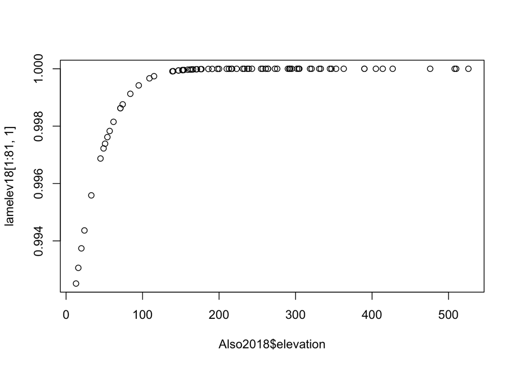

```r
#2018
lamelev18 <- occSSrn(Also2018DH, model = lambda ~ elevation, data = Also2018)
lamelev18 <- as.data.frame(lamelev18[["real"]])
#psi vs elevation
plot(Also2018$elevation,lamelev18[1:81,1])
```

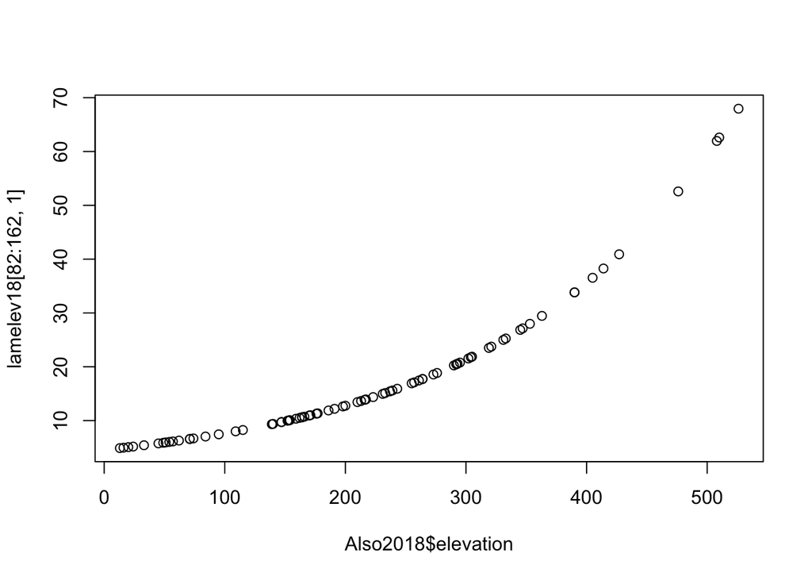

```r
#lambda vs elevation
plot(Also2018$elevation,lamelev18[82:162,1])
```

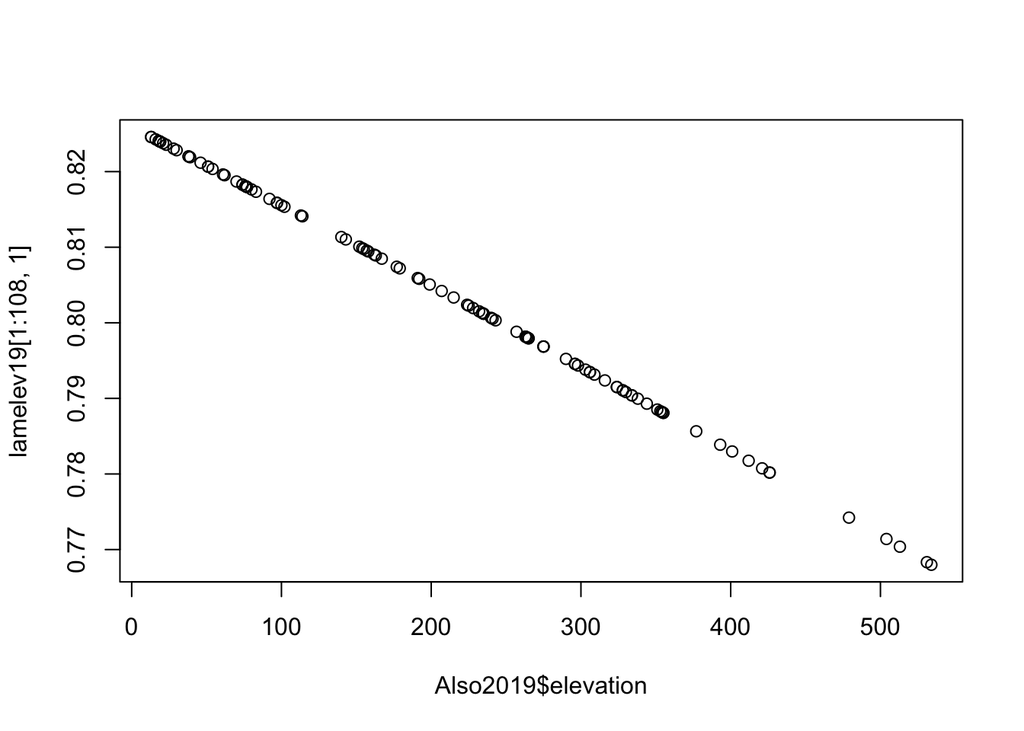

```r
###
#2019
lamelev19 <- occSSrn(Also2019DH, model = lambda ~ elevation, data = Also2019)
lamelev19 <- as.data.frame(lamelev19[["real"]])
#psi vs elevation
plot(Also2019$elevation,lamelev19[1:108,1])
```

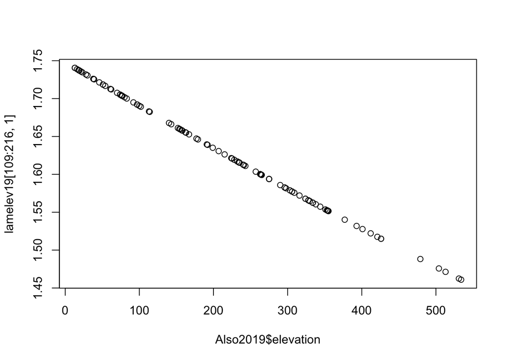

```r
#lambda vs elevation
plot(Also2019$elevation,lamelev19[109:216,1])
```

```r
#2018 alone
occMS(Also2018DH, 24, data=Also2018)
```

```
## Call: occMS0(DH = DH, occsPerSeason = occsPerSeason, ci = ci, verify = FALSE)
##
## Real values (duplicates omitted):
##           est lowCI uppCI
## psi1  0.72756    NA    NA
## gamma 0.50000    NA    NA
## p     0.05016    NA    NA
##
## AIC: NA
```

```r
data(GrandSkinks)
head(GrandSkinks)
```

|  | A1 | A2 | A3 | B1 | B2 | B3 | C1 | C2 | C3 | D1 | D2 | D3 | E1 | E2 | E3 | habitat |
| --- | --- | --- | --- | --- | --- | --- | --- | --- | --- | --- | --- | --- | --- | --- | --- | --- |
| 1 | 0 | 0 | 0 | 0 | 0 | 0 | 0 | 0 | NA | 0 | 0 | 0 | 0 | 0 | 0 | Pasture |
| 2 | 0 | 0 | 0 | 0 | 0 | NA | 0 | 0 | 0 | 0 | 0 | 0 | 0 | 0 | 0 | Pasture |
| 3 | 0 | 0 | 0 | 0 | 0 | NA | 0 | 0 | 0 | 0 | 0 | 0 | 0 | 0 | 0 | Pasture |
| 4 | 0 | NA | NA | 0 | NA | NA | 0 | NA | NA | 0 | 0 | NA | 0 | NA | NA | Pasture |
| 5 | 0 | NA | NA | NA | NA | NA | NA | NA | NA | NA | NA | NA | 0 | NA | NA | Pasture |
| 6 | 0 | NA | NA | NA | NA | NA | NA | NA | NA | NA | NA | NA | 0 | NA | NA | Pasture |

```r
data(weta)
head(weta)
```

|  | D1 | D2 | D3 | D4 | D5 | Browsed | ObsD1 | ObsD2 | ObsD3 | ObsD4 | ObsD5 |
| --- | --- | --- | --- | --- | --- | --- | --- | --- | --- | --- | --- |
| 1 | 0 | 0 | 0 | 0 | NA | TRUE | A | C | B | C | NA |
| 2 | 0 | 0 | 0 | 0 | NA | TRUE | A | C | B | C | NA |
| 3 | 0 | 0 | 0 | 1 | NA | TRUE | A | C | B | C | NA |
| 4 | 0 | 0 | 0 | 0 | NA | FALSE | A | C | B | C | NA |
| 5 | 0 | 0 | 0 | 0 | NA | TRUE | A | C | B | C | NA |
| 6 | 0 | 0 | 0 | 0 | NA | FALSE | A | C | B | C | NA |

```r
#testing
data(GrandSkinks)
DH <- GrandSkinks[, 1:15]

occMS0(DH, 3)
```

```
## Call: occMS0(DH = DH, occsPerSeason = 3)
##
## Real values:
##             est   lowCI   uppCI
## psi1    0.39450 0.33475 0.45759
## gamma   0.06829 0.04839 0.09554
## epsilon 0.10001 0.06948 0.14192
## p       0.68915 0.64222 0.73250
##
## AIC: 1775.015
```

```r
occMStime(DH, 3, model=list(gamma ~ .interval, epsilon~1, p~.season))
```

```
## Call: occMStime(DH = DH, occsPerSeason = 3, model = list(gamma ~ .interval,
##     epsilon ~ 1, p ~ .season))
##
## Real values (duplicates omitted):
##          est    lowCI  uppCI
## psi1 0.38496 0.319995 0.4543
## gam1 0.11860 0.061710 0.2159
## gam2 0.01527 0.001163 0.1711
## gam3 0.07222 0.037156 0.1357
## gam4 0.09667 0.052560 0.1711
## eps1 0.09865 0.067173 0.1426
## p1   0.69273 0.569878 0.7932
## p2   0.65359 0.563057 0.7342
## p3   0.69616 0.611982 0.7690
## p4   0.82857 0.722633 0.8997
## p5   0.61062 0.507160 0.7050
##
## AIC: 1771.799
```

```r
occMScovSite(DH, 3,
   model=list(psi1~habitat, gamma ~ .interval, epsilon~habitat, p~.season),
   data=GrandSkinks)
```

```
## Call: occMScovSite(DH = DH, occsPerSeason = 3, model = list(psi1 ~
##     habitat, gamma ~ .interval, epsilon ~ habitat, p ~ .season),
##     data = GrandSkinks)
##
## Real values (duplicates omitted):
##                   est    lowCI  uppCI
## psi:1         0.22640 0.153977 0.3200
## psi:138       0.52535 0.428414 0.6204
## gamma:1,1     0.09092 0.037891 0.2025
## gamma:1,2     0.01995 0.002735 0.1313
## gamma:1,3     0.07338 0.037610 0.1383
## gamma:1,4     0.09892 0.054518 0.1729
## epsilon:1,1   0.17427 0.104875 0.2754
## epsilon:138,1 0.07686 0.046198 0.1252
## p:1,1         0.64860 0.515433 0.7621
## p:1,2         0.65864 0.568371 0.7387
## p:1,3         0.69303 0.608569 0.7663
## p:1,4         0.82998 0.729596 0.8983
## p:1,5         0.60978 0.508240 0.7026
##
## AIC: 1745.792
```

```r
occMS(DH, 3,
      model=list(psi1~habitat, gamma ~ .interval, epsilon~habitat, p~.season),
   data=GrandSkinks)
```

```
## Call: occMS(DH = DH, occsPerSeason = 3, model = list(psi1 ~ habitat,
##     gamma ~ .interval, epsilon ~ habitat, p ~ .season), data = GrandSkinks)
##
## Real values (duplicates omitted):
##                   est    lowCI  uppCI
## psi:1         0.22640 0.153977 0.3200
## psi:138       0.52535 0.428414 0.6204
## gamma:1,1     0.09092 0.037891 0.2025
## gamma:1,2     0.01995 0.002735 0.1313
## gamma:1,3     0.07338 0.037610 0.1383
## gamma:1,4     0.09892 0.054518 0.1729
## epsilon:1,1   0.17427 0.104875 0.2754
## epsilon:138,1 0.07686 0.046198 0.1252
## p:1,1         0.64860 0.515433 0.7621
## p:1,4         0.65864 0.568371 0.7387
## p:1,7         0.69303 0.608569 0.7663
## p:1,10        0.82998 0.729596 0.8983
## p:1,13        0.60978 0.508240 0.7026
##
## AIC: 1745.792
```